[figure not shown]

# A Jupyter Notebook for Spectral Analysis of time-uncertain Marine Data

# Introduction

This notebook works through the step of obtaining an ensemble of possible age models for the marine chronology and obtain the time-uncertain spectrum for the time series.

**NOTE**

Haslett, J., Parnell, A. (2008). *A simple monotone process with application to radiocarbon-dated depth chronologies.* Journal of the Royal Statistical Society: Series C (Applied Statistics), 57, 4, 1467-9876. doi: 10.1111/j.1467-9876.2008.00623.x

# Running this Notebook

### Software

1. Jupyter Notebook
2. Python 3.4+ with the following modules:
   1. lipd 1.2+ (pip install lipd)
   2. numpy (standard with Anaconda Install)
   3. pandas (standard with Anaconda Install)
   4. matplotlib (standard with Anaconda Install)
3. An up-to-date version of R installed on your computer
4. The Bchron package. In a R console, type install.packages('Bchron')

### Record

A record in LiPD format. This notebook assumes that the column are organized using this format. To learn more about LiPD and utilities to format your dataset, vist this [page](https://github.com/nickmckay/LiPD-utilities).

**NOTE**

A Welcome to LiPD guide is also available in a Jupyter Notebook, created in the root directory of your computer when you intalled the lipd module.

# Import a LiPD file

```python
# Import the LiPD package and locate your files
import lipd as lpd
import pandas as pd
import numpy as np
import matplotlib.pyplot as plt
import cartopy
import cartopy.crs as ccrs
import sys
import os
```

[output not shown]

```
Trying `CDLL(/usr/lib/libc.dylib)`
Library path: '/usr/lib/libc.dylib'
DLL: <CDLL '/usr/lib/libc.dylib', handle 7fff5c0cbd08 at 0x1251bba90>
```

```python
# Load the LiPD file
lpd.loadLipds()
```

```
Found: 1 LiPD file(s)
processing: MD982181.Khider.2014.lpd
Process Complete
```

The cell below contains some basic functions to manipulate LiPD files. Full implementation in Pyleoclim is pending

```python
# Functions needed to move things arounf LiPD files
#%% Lipd Utils

def findLipds(path):
    """
    Find all the lipd files in a directory
    """

    files = os.listdir(path)
    lipd_in_directory = [i for i in files if i.endswith('.lpd')]

    return lipd_in_directory

def createdir(path, foldername):
    """
    create a new folder in the working directory
    """

    if not os.path.exists(path+'/'+foldername):
        os.makedirs(path+'/'+foldername)

    newdir = path+'/'+foldername

    return newdir

def enumerateLipds(path):
    """
    enumerate the LiPDs in the directory and allows to select one
    """
    lipd_in_directory = findLipds(path)
    print("Below are the available records")
    for idx, val in enumerate(lipd_in_directory):
        print(idx,': ',val)

def promptforLipd():
    """
    Ask the user to select a LiPD file from a list
    Use this function in conjunction with enumerateLipds()
    """
    select_lipd = int(input("Enter the number of the file you wish to analyze: "))
    return select_lipd

def readHeaders(Dataframe):
    """
    read and returns the column headers of a panda Dataframe
    """
    index = 0
    for key, value in Dataframe.items():
        print(index,": ",key)
        index+=1

def promptforVariable():
    """
    Ask the user to select the variable they are interested in.
    Use this function in conjunction with readHeaders()
    """
    select_var = int(input("Enter the number of the variable you wish to use: "))
    return select_var

def selectVariable(Dataframe, varName):
    """
    Select a specific column in a panda dataframes based on the variable name
    in the LinkedEarth Ontology
    Inputs: the dataframe and the name of the variable to search for
    """
    index =0 #index header
    index_option=[]# keep the index
    option = [] #number of columns meeting the varName criteria
    for key,val in Dataframe.items():
        if varName in key.lower():
            index_option.append(index)
            option.append(key)
        index+=1
    # if there is only one option, select it by default
    index = 0 #reset the counter
    if len(option)==1:
        var_idx= index_option[0]
        label = option[0]
    elif len(option)==0:
        print("Only the following variables are available: ")
        readHeaders(Dataframe)
        var_idx = promptforVariable()
        label = Dataframe.columns.values[var_idx]
    else:
        print("There is more than one option available")
        for val in option:
            print(index,": ",val)
            index+=1
        option_index = int(input("Enter the index of the variable of interest: "))
        var_idx = index_option[option_index]
        label = option[option_index]

    return var_idx, label


def promptforXaxis(Dataframe):
    """
    read the column headers and try to determine the choice for x-axis
    """
    index =0 #index header
    index_option=[]# keep the index
    x_option = [] #number of depth/age column
    for key,val in Dataframe.items():
        if 'age' in key.lower() or 'depth' in key.lower():
            index_option.append(index)
            x_option.append(key)
        index+=1
    # if there is only one option, select it by default
    index = 0 #reset the counter
    if len(x_option)==1:
        x_axis_idx= index_option[0]
        x_axis_label = x_option[0]
    else:
        print("There is more than one option available")
        for val in x_option:
            print(index,": ",val)
            index+=1
        x_index = int(input("Enter the index for the x-axis representation: "))
        x_axis_idx = index_option[x_index]
        x_axis_label = x_option[x_index]

    return x_axis_idx, x_axis_label

def getDataframe(filename="", refine="paleo", tablenumber=[]):
    """
    Get the data to be analyzed in the proper dataframe
    Inputs:
        - filename: if unknown, will prompt. Need the .lpd extension
        - refine: which data are you interested in. Two options: paleo, chron. Default is paleo.
        - tablenumber: if there are multiple datatables, enter the number of the table. Default is unknown
    """
    # Get the name of the LiPD file
    if not filename:
        lipd_in_directory=findLipds(lpd.path)
        enumerateLipds(lpd.path)
        filename = lipd_in_directory[promptforLipd()]

    # Get the names of the
    c = lpd.getCsv(filename)

    tablename=[]
    for key, value in c.items():
        if refine in key.lower():
            tablename.append(key)
    if len(tablename) == 1:
        tablename = tablename[0]
    elif len(tablename) == 0:
        sys.exit("No table match your selection criteria")
    else:
        if not tablenumber:
            print("More than one table match the search criteria")
            for idx, val in enumerate(tablename):
                print(idx,": ",val)
            tablenumber=int(input("Which one would you like to use? "))
        tablename=tablename[tablenumber]

    dfs_lipd = lpd.lipdToDf(filename)
    DataFrame = dfs_lipd[refine+"Data"][tablename]

    return DataFrame, filename

def stopFunction(answer,keyword, message):
    """
    Allows to exit the the function using a specific keyword in the prompt
    and return an error message.
    """
    if answer == keyword:
        sys.exit(message)

def recordID(filename=""):
    """
    Get basic information about a record:
        - name
        - archiveType
        - Authors
    """
    if not filename:
        lipd_in_directory=findLipds(lpd.path)
        enumerateLipds(lpd.path)
        filename = lipd_in_directory[promptforLipd()]

    # get the medatadata
    lipd_m = lpd.getMetadata(filename)
    name = lipd_m['dataSetName'] # get the name
    archivetype = lipd_m['archiveType'] # get the archive type
    authors_list=[]
    # Loop through the list of contributors
    for key,val in enumerate(lipd_m['investigator']):
        authors_list.append(val['name'])
    # Convert to a string
    authors = ', '.join(str(e) for e in authors_list)
    if len(authors_list)>1:
        authors_short = authors_list[0]+ " et al."
    else:
        authors_short = authors
    return name, archivetype, authors, authors_short

def get_recursively(search_dict, field):
    """Takes a dict with nested lists and dicts,
    and searches all dicts for a key of the field
    provided.
    """
    fields_found = []

    for key, value in search_dict.items():

        if key == field:
            fields_found.append(value)

        elif isinstance(value, dict):
            results = get_recursively(value, field)
            for result in results:
                fields_found.append(result)

        elif isinstance(value, list):
            for item in value:
                if isinstance(item, dict):
                    more_results = get_recursively(item, field)
                    for another_result in more_results:
                        fields_found.append(another_result)

    return fields_found

def valuesloc(filename="", refine="paleo", tablenumber=[], varName=""):
    """
    Look for the indexes where there are no missing values for the variable
    """
    # Get the dataframe
    dataframe, filename = getDataframe(filename=filename, refine = refine, tablenumber=tablenumber)
    # Now get the metadata dictionary
    lipd_m = lpd.getMetadata(filename)
    # Get the missing values handle
    value = get_recursively(lipd_m, "missingValue")

    # Check that there is only one possible handle for missing values, if not
    # prompt the users for the right one.
    unique=[] # create the unique list
    for i in value:
        if i not in unique:
            unique.append(i)
    if len(unique)>1:
        print("Missing values were flagged in the following ways: ")
        for key, val in enumerate(unique):
            print(key,": ", val)
        answer = int(input("Which one would you like to use? "))
        missing_value = unique[answer]
    else:
        missing_value = unique[0]

    # if the variable name is not given or doesn't exist prompt
    if not varName:
        print("Below is a list of variables: ")
        readHeaders(dataframe)
        var_idx = promptforVariable()
    else:
        var_idx, label = selectVariable(dataframe, varName)

    # Get the index with the appropriate values
    val_idx = [] #Initiate the counter
    if missing_value == 'NaN':
        for n,i in enumerate(dataframe.iloc[:,var_idx]):
            if not np.isnan(i):
                val_idx.append(n)
    else:
        for n,i in enumerate(dataframe.iloc[:,var_idx]):
            if i!=float(missing_value):
                val_idx.append(n)

    return val_idx
```

# Set-up

## Get the data and metadata

```python
# Get the metadata (To display lat/lon)

lipd_m = lpd.getMetadata("MD982181.Khider.2014.lpd")

record = lipd_m['geo']['properties']['siteName']
```

```
Process Complete
```

```python
# Get the paleodata in a Panda DataFrame for ease of use

df_data_l, filename = getDataframe(filename="MD982181.Khider.2014.lpd", refine="paleo", tablenumber=2)
df_data_l
```

```
Process Complete
Process Complete
```

|  | age | age_calyrbp | d18og | depth_cm | mg | sst | δ18osw | δ18osw 2 | δ18osw 34 | δ18osw 68 | δ18osw 97 |
| --- | --- | --- | --- | --- | --- | --- | --- | --- | --- | --- | --- |
| 0 | 428.0 | 199.0 | NaN | 1.0 | 5.21 | 28.74 | NaN | NaN | NaN | NaN | NaN |
| 1 | 429.0 | 205.0 | -2.830 | 2.5 | 5.04 | 28.35 | 0.02 | -0.32 | -0.05 | 0.10 | 0.35 |
| 2 | 430.0 | 207.0 | -2.810 | 3.0 | NaN | NaN | NaN | NaN | NaN | NaN | NaN |
| 3 | 432.0 | 211.0 | -2.780 | 4.0 | NaN | NaN | NaN | NaN | NaN | NaN | NaN |
| 4 | 433.0 | 216.0 | -2.788 | 5.0 | 5.10 | 28.49 | 0.09 | -0.25 | 0.01 | 0.17 | 0.43 |
| 5 | 435.0 | 222.0 | -2.854 | 6.5 | 4.93 | 28.12 | -0.06 | -0.40 | -0.13 | 0.03 | 0.28 |
| 6 | 435.0 | 224.0 | -2.569 | 7.0 | 5.01 | 28.32 | 0.27 | -0.08 | 0.19 | 0.35 | 0.61 |
| 7 | 437.0 | 228.0 | -2.925 | 8.0 | 5.09 | 28.49 | -0.05 | -0.40 | -0.12 | 0.03 | 0.28 |
| 8 | 438.0 | 232.0 | -2.802 | 9.0 | NaN | NaN | NaN | NaN | NaN | NaN | NaN |
| 9 | 441.0 | 241.0 | -2.502 | 11.0 | NaN | NaN | NaN | NaN | NaN | NaN | NaN |
| 10 | 441.0 | 243.0 | -2.504 | 11.5 | 5.22 | 28.73 | 0.43 | 0.10 | 0.36 | 0.51 | 0.76 |
| 11 | 442.0 | 245.0 | -2.823 | 12.0 | NaN | NaN | NaN | NaN | NaN | NaN | NaN |
| 12 | 444.0 | 249.0 | -2.692 | 13.0 | 5.17 | 28.65 | 0.21 | -0.12 | 0.15 | 0.30 | 0.55 |
| 13 | 447.0 | 257.0 | -2.900 | 15.0 | 5.30 | 28.95 | 0.07 | -0.27 | 0.00 | 0.15 | 0.41 |
| 14 | 448.0 | 261.0 | -2.640 | 16.0 | 5.14 | 28.58 | 0.25 | -0.08 | 0.19 | 0.34 | 0.59 |
| 15 | 449.0 | 264.0 | -2.616 | 16.5 | NaN | NaN | NaN | NaN | NaN | NaN | NaN |
| 16 | 454.0 | 274.0 | -2.705 | 19.0 | 4.95 | 28.17 | 0.10 | -0.24 | 0.03 | 0.18 | 0.44 |
| 17 | 458.0 | 282.0 | -2.733 | 21.0 | 4.79 | 27.80 | 0.00 | -0.35 | -0.07 | 0.08 | 0.34 |
| 18 | 461.0 | 291.0 | -2.956 | 23.0 | 4.98 | 28.25 | -0.13 | -0.47 | -0.20 | -0.05 | 0.21 |
| 19 | 463.0 | 295.0 | -3.024 | 24.0 | 5.31 | 28.97 | -0.05 | -0.39 | -0.12 | 0.03 | 0.28 |
| 20 | 465.0 | 299.0 | -3.006 | 25.0 | 5.24 | 28.78 | -0.07 | -0.40 | -0.13 | 0.01 | 0.26 |
| 21 | 470.0 | 307.0 | -2.404 | 27.0 | 5.29 | 28.91 | 0.56 | 0.22 | 0.49 | 0.64 | 0.90 |
| 22 | 471.0 | 311.0 | -2.494 | 28.0 | 5.36 | 29.05 | 0.50 | 0.17 | 0.43 | 0.58 | 0.83 |
| 23 | 475.0 | 319.0 | -3.010 | 30.0 | 5.12 | 28.54 | -0.13 | -0.46 | -0.19 | -0.04 | 0.21 |
| 24 | 476.0 | 324.0 | -2.584 | 31.0 | 5.08 | 28.46 | 0.28 | -0.05 | 0.22 | 0.37 | 0.62 |
| 25 | 482.0 | 336.0 | -2.681 | 34.0 | 5.07 | 28.43 | 0.18 | -0.15 | 0.12 | 0.27 | 0.53 |
| 26 | 484.0 | 340.0 | -2.722 | 35.0 | NaN | NaN | NaN | NaN | NaN | NaN | NaN |
| 27 | 489.0 | 348.0 | -2.723 | 37.0 | 5.00 | 28.31 | 0.11 | -0.23 | 0.04 | 0.19 | 0.45 |
| 28 | 492.0 | 352.0 | -2.874 | 38.0 | 5.74 | 29.77 | 0.28 | -0.05 | 0.21 | 0.35 | 0.62 |
| 29 | 494.0 | 356.0 | -2.666 | 39.0 | 5.00 | 28.29 | 0.16 | -0.18 | 0.10 | 0.25 | 0.51 |
| ... | ... | ... | ... | ... | ... | ... | ... | ... | ... | ... | ... |
| 425 | 7884.0 | 7764.0 | -2.627 | 741.0 | 5.23 | 28.77 | 0.23 | -0.10 | 0.16 | 0.31 | 0.58 |
| 426 | 7919.0 | 7797.0 | -2.676 | 743.0 | 4.83 | 27.91 | 0.00 | -0.35 | -0.08 | 0.08 | 0.34 |
| 427 | 7953.0 | 7830.0 | -2.538 | 745.0 | 5.21 | 28.72 | 0.31 | -0.04 | 0.24 | 0.39 | 0.65 |
| 428 | 7988.0 | 7863.0 | -2.615 | 747.0 | 5.08 | 28.44 | 0.17 | -0.16 | 0.11 | 0.26 | 0.52 |
| 429 | 8023.0 | 7897.0 | -2.545 | 749.0 | 5.35 | 29.00 | 0.36 | 0.02 | 0.29 | 0.44 | 0.69 |
| 430 | 8129.0 | 8001.0 | -2.550 | 755.0 | 5.24 | 28.79 | 0.31 | -0.02 | 0.24 | 0.39 | 0.65 |
| 431 | 8202.0 | 8072.0 | -2.330 | 759.0 | 5.63 | 29.58 | 0.69 | 0.36 | 0.62 | 0.77 | 1.01 |
| 432 | 8239.0 | 8108.0 | -2.040 | 761.0 | 5.64 | 29.61 | 0.98 | 0.65 | 0.91 | 1.06 | 1.32 |
| 433 | 8277.0 | 8145.0 | -2.270 | 763.0 | 5.41 | 29.14 | 0.65 | 0.32 | 0.58 | 0.73 | 0.99 |
| 434 | 8354.0 | 8220.0 | -2.140 | 767.0 | 5.65 | 29.62 | 0.87 | 0.55 | 0.81 | 0.96 | 1.22 |
| 435 | 8432.0 | 8296.0 | -2.590 | 771.0 | 5.46 | 29.25 | 0.34 | 0.01 | 0.27 | 0.42 | 0.67 |
| 436 | 8511.0 | 8375.0 | -2.620 | 775.0 | NaN | NaN | NaN | NaN | NaN | NaN | NaN |
| 437 | 8592.0 | 8455.0 | -2.300 | 779.0 | 5.45 | 29.24 | 0.61 | 0.28 | 0.54 | 0.69 | 0.95 |
| 438 | 8676.0 | 8536.0 | -2.360 | 783.0 | NaN | NaN | NaN | NaN | NaN | NaN | NaN |
| 439 | 8738.0 | 8598.0 | -2.500 | 786.0 | 5.25 | 28.80 | 0.31 | -0.03 | 0.24 | 0.39 | 0.64 |
| 440 | 8845.0 | 8703.0 | -2.180 | 791.0 | 5.43 | 29.19 | 0.70 | 0.36 | 0.63 | 0.78 | 1.04 |
| 441 | 8910.0 | 8767.0 | -2.460 | 794.0 | 5.45 | 29.24 | 0.42 | 0.09 | 0.35 | 0.51 | 0.76 |
| 442 | 9019.0 | 8875.0 | -2.200 | 799.0 | 5.18 | 28.68 | 0.56 | 0.22 | 0.49 | 0.64 | 0.90 |
| 443 | 9108.0 | 8963.0 | -2.180 | 803.0 | 4.96 | 28.21 | 0.47 | 0.13 | 0.39 | 0.55 | 0.81 |
| 444 | 9199.0 | 9052.0 | -2.410 | 807.0 | 5.29 | 28.89 | 0.38 | 0.05 | 0.31 | 0.46 | 0.72 |
| 445 | 9290.0 | 9142.0 | NaN | 811.0 | 5.48 | 29.30 | NaN | NaN | NaN | NaN | NaN |
| 446 | 9383.0 | 9233.0 | -2.410 | 815.0 | 5.35 | 29.04 | 0.39 | 0.06 | 0.32 | 0.47 | 0.72 |
| 447 | 9477.0 | 9324.0 | NaN | 819.0 | 5.54 | 29.39 | NaN | NaN | NaN | NaN | NaN |
| 448 | 9571.0 | 9417.0 | -2.320 | 823.0 | 5.71 | 29.71 | 0.61 | 0.29 | 0.55 | 0.69 | 0.95 |
| 449 | 9667.0 | 9510.0 | -2.440 | 827.0 | 5.53 | 29.39 | 0.41 | 0.08 | 0.35 | 0.49 | 0.74 |
| 450 | 9764.0 | 9604.0 | -2.580 | 831.0 | NaN | NaN | NaN | NaN | NaN | NaN | NaN |
| 451 | 9886.0 | 9722.0 | -2.650 | 836.0 | 5.14 | 28.59 | 0.01 | -0.33 | -0.06 | 0.09 | 0.34 |
| 452 | 9960.0 | 9793.0 | -2.620 | 839.0 | 5.77 | 29.88 | 0.30 | -0.04 | 0.23 | 0.38 | 0.63 |
| 453 | 10059.0 | 9888.0 | -2.640 | 843.0 | 5.45 | 29.19 | 0.13 | -0.20 | 0.07 | 0.22 | 0.47 |
| 454 | 10134.0 | 9960.0 | -2.530 | 846.0 | 5.42 | 29.16 | 0.22 | -0.10 | 0.15 | 0.31 | 0.56 |

455 rows × 11 columns

```python
# Get the chrondata in a panda dataframe for ease of use

df_chron_l, filename = getDataframe(filename="MD982181.Khider.2014.lpd", refine="chron")
df_chron_l
```

```
Process Complete
Process Complete
```

|  | age14c | age14cuncertainty | calendarage | calendarageuncertainty | cams | depth | species |
| --- | --- | --- | --- | --- | --- | --- | --- |
| 0 | 580.0 | 110.0 | 269.0 | 222.0 | OS-36493 | 12.0 | Gs |
| 1 | 815.0 | 200.0 | 491.0 | 395.0 | OS-37308 | 55.0 | Gs/Gr |
| 2 | 1010.0 | 100.0 | 688.0 | 205.0 | OS-37292 | 99.0 | Gs/Gr |
| 3 | 1090.0 | 120.0 | 742.0 | 242.0 | OS-37306 | 145.0 | Gs |
| 4 | 1750.0 | 15.0 | 1389.0 | 149.0 | 90357 | 201.0 | MP |
| 5 | 1900.0 | 100.0 | 1551.0 | 262.0 | OS-36485 | 238.0 | Gs |
| 6 | 2575.0 | 20.0 | 2368.0 | 232.0 | 104528 | 351.0 | Gs/Gr |
| 7 | 3960.0 | 150.0 | 4069.0 | 433.0 | OS-37289 | 402.0 | Gs |
| 8 | 4070.0 | 190.0 | 4245.0 | 530.0 | OS-37303 | 501.0 | Gs |
| 9 | 4925.0 | 30.0 | 5344.0 | 216.0 | 104529 | 610.0 | Gs/Gr |
| 10 | 6950.0 | 50.0 | 7519.0 | 1153.0 | OS-34874 | 711.0 | Gs |
| 11 | 7360.0 | 50.0 | 7891.0 | 193.0 | OS-34875 | 755.0 | Gs |
| 12 | 9480.0 | 55.0 | 10395.0 | 175.0 | OS-34876 | 861.0 | Gs |
| 13 | 11050.0 | 310.0 | 12488.0 | 803.0 | OS-36478 | 941.0 | Gs |

```python
# Get the radiocarbon data
var_idx, label = selectVariable(df_chron_l, "radiocarbon")
radiocarbon = df_chron_l.iloc[:,var_idx]
```

```
Only the following variables are available:
0 :  age14c
1 :  age14cuncertainty
2 :  calendarage
3 :  calendarageuncertainty
4 :  cams
5 :  depth
6 :  species
Enter the number of the variable you wish to use: 0
```

```python
# Get the radiocarbon data
var_idx, label = selectVariable(df_chron_l, "radiocarbonU")
radiocarbonU = df_chron_l.iloc[:,var_idx]
```

```
Only the following variables are available:
0 :  age14c
1 :  age14cuncertainty
2 :  calendarage
3 :  calendarageuncertainty
4 :  cams
5 :  depth
6 :  species
Enter the number of the variable you wish to use: 1
```

```python
# Create a working directory

dir = createdir(lpd.path,"Age Model")
```

## Reservoir Age Correction

```python
# Get the latitude and longitude from the metadata

print("Latitude: " + str(lipd_m.get('geo').get('geometry').get('coordinates')[0]))
print("Longitude: " + str(lipd_m.get('geo').get('geometry').get('coordinates')[1]))
```

```
Latitude: 125.83
Longitude: 6.45
```

**NOTE**

The cell below will automatically "paste" the reservoir age correction table from this [website](http://intcal.qub.ac.uk/marine/). Enter the latitude/longitude from above and check the boxes 'ReservoirAge' and 'ReservoirErr'.

Select the entire table, **including** the headers.

Make sure that the table is the last item copied to the clipboard. You will get a chance to check it before continuing.

A copy of the table is automatically saved as a text file as part of the routine.

This **only** works with Safari or Google Chrome.

```python
import pandas as pd
import numpy as np
import math

data = pd.read_clipboard()

# check your work

print("Don't forget to check your work!")
data
```

```
Don't forget to check your work!
```

[output not shown]

```python
# Calculate the average DR and standard error of the mean

corr = data.mean()['DeltaR']
corr_err = data.std()['DeltaR']
```

```python
# Perform the correction

corr_14C = np.floor((radiocarbon - corr).values)
err_14C = np.floor(np.sqrt(radiocarbonU**2 + corr_err**2).values)
```

## Prepare Bchron data and metadata

The next cell prepares the text file necessary for the Bchron run.

**NOTE**

This version of the Jupyter Notebook only allows radiocarbon data as tie points.

```python
# Generate the radiocarbon data for Bchron input

# Get the Id column
Id = []
for i in np.arange(0,corr_14C.size,1):
    Id.append(record + '_' + str(i+1))

# Get the depth column
var_idx, label = selectVariable(df_chron_l, "depth")
depth = df_chron_l.iloc[:,var_idx]

# Create the dataframe
radio = pd.DataFrame({'Id': Id,
                    'ages' : corr_14C,
                    'ageSds' : err_14C,
                    'position' : depth,
                    'CalCurves' : 'marine13'})
# Save it to a text file

radio.to_csv(lpd.path +'/Age model/'+ record +'_radiocarbon.txt', sep = '\t', index = False, header = True)

# Let's generate the positions for the new age model
var_idx, label = selectVariable(df_data_l, "depth")
df_data_l.to_csv(lpd.path +'/Age model/' + record + '_depth.txt',columns = [label], index = False, header = False)
```

```python
# Return some strings for use in Bchron
radio_text = record + '_radiocarbon.txt'
depth_text = record + '_depth.txt'
```

# Bchron Run

Setup some of Bchron optional arguments. Set the collection age of the core if known and the number of simulations to 10000 to get 1000 age model samples back

```python
# Let Python and R communicate with each other

%load_ext rpy2.ipython

# Ignore the error message
```

```python
iter = 10000
max_t = -48

# Pass the needed variable into R

%R -i iter
%R -i dir
%R -i radio_text
%R -i depth_text
%R -i max_t
%R -i record
```

Perform the Bchron run and return the plot

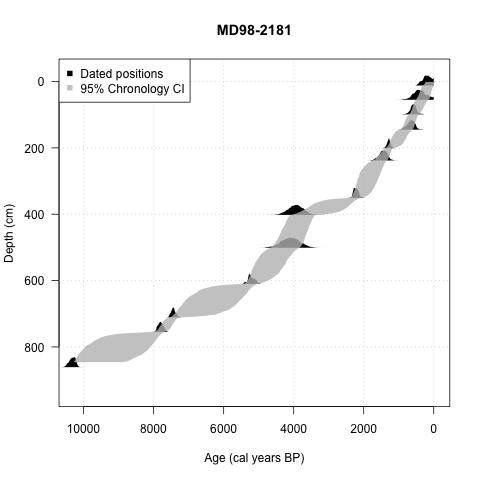

```python
%%R

library(Bchron)
setwd(dir)
library("Bchron", lib.loc="/Library/Frameworks/R.framework/Versions/3.2/Resources/library")
radiocarbon_data <- read.delim(radio_text)
depth_data <- read.table(depth_text, quote="\"")
run=Bchronology(ages=radiocarbon_data$ages,ageSds=radiocarbon_data$ageSds,
                calCurves=radiocarbon_data$CalCurves,positions=radiocarbon_data$position,
                predictPositions=depth_data$V1,iterations=iter,extractDate=max_t)
plot(run,main=record,xlab='Age (cal years BP)',ylab='Depth (cm)',las=1)
```

```python
# Pass some variables back into Python for further analysis
depth_paleo = %R run$predictPositions
age_paleo = %R run$thetaPredict
depth_chron = %R run$positions
age_chron = %R run$theta
```

```python
# Create the ensembleArray and try to save
ensembleArray = np.insert(age_paleo.T,0,depth_paleo,axis=1)

# Save it to a dataframe (needs fixing)
#lpd.addEnsemble(filename,ensembleArray)
```

## Age model plot

Plot the age model with the uncertainty cloud and save the resulting graph in the Figures subdirectory.

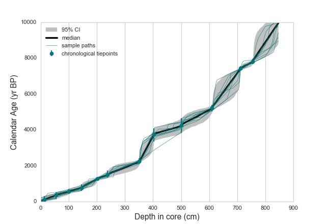

```python
# Calculate the quantiles
from scipy.stats.mstats import mquantiles
age_paleo_Q  = mquantiles(age_paleo, prob=[0.025, 0.5, 0.975], axis=0)
age_chron_Q  = mquantiles(age_chron, prob=[0.025, 0.5, 0.975], axis=0)
nchrons = age_paleo.shape[0]

# Plot it out
%matplotlib notebook
import seaborn as sns;
import matplotlib.patches as mpatches
sns.set(style='whitegrid', palette='Set2')
ax = plt.axes()
#ax.spines["top"].set_visible(False)
#ax.spines["right"].set_visible(False)
plt.fill_between(depth_paleo, age_paleo_Q[0,:], age_paleo_Q[2,:], facecolor='Silver',edgecolor='Silver',lw=0.0)  # see http://stackoverflow.com/questions/14143092/why-does-matplotlib-fill-between-draw-edgelines-only-on-a-pdf
CI = mpatches.Patch(color='silver') # create proxy artist for labeling
lbl = ('95% CI','median','sample paths','chronological tiepoints')
med, = ax.plot(depth_paleo,age_paleo_Q[1,],color = 'black', lw=3.0)

#plot a few random paths
nl = 10
idx = np.random.randint(nchrons+1, size=nl)
l = ax.plot(depth_paleo,age_paleo[idx,:].T,lw=0.5,color = '#047878')

# Plot the age tie points with
yerr_low= age_chron_Q[1,:]-age_chron_Q[0,:]
yerr_high = age_chron_Q[2,:]-age_chron_Q[1,:]
v = ax.errorbar(depth_chron,age_chron_Q[1,:],yerr=[yerr_low,yerr_high], fmt='o', color = '#047878')

# plot the legend
lg = plt.legend((CI,med,l[1], v),lbl,loc='upper left'); lg.draw_frame(False)
ax.grid(axis='y');
plt.ylim(0,10000);  plt.xlim(0,900)
ax.get_xaxis().tick_bottom()
ax.get_yaxis().tick_left()
plt.xlabel(r'Depth in core (cm)',fontsize=14); plt.ylabel(r'Calendar Age (yr BP)',fontsize=14);
```

```python
# Save the figure
newdir = createdir(lpd.path,'Figures')
plt.savefig(newdir+'/plot_agemodel_'+filename+'.eps', bbox_inches = 'tight', pad_inches =0.25)
```

# Spectral Analysis

Use the Lomb-Scargle periodogram for unevenly-spaced time series from the scipy package.

```python
var_idx, label = selectVariable(df_data_l,"Mg/Ca")
```

```
Only the following variables are available:
0 :  age
1 :  age_calyrbp
2 :  d18og
3 :  depth_cm
4 :  mg
5 :  sst
6 :  δ18osw
7 :  δ18osw 2
8 :  δ18osw 34
9 :  δ18osw 68
10 :  δ18osw 97
Enter the number of the variable you wish to use: 4
```

```python
#Look for the indices of the missing values (Dataframe given above if more than one value found for the entire dataset)
val_idx = valuesloc(filename="MD982181.Khider.2014.lpd", refine="paleo", tablenumber=2, varName=label)
```

```
Process Complete
Process Complete
Process Complete
Missing values were flagged in the following ways:
0 :  NaN
1 :  -999.9
2 :  -999.99
Which one would you like to use? 0
```

```python
# Get the proxy and chron data on the right indices
y_values = df_data_l.iloc[val_idx,var_idx]
age_paleo_nan = age_paleo[:,val_idx]
```

```python
# Filter for Holocene value
age_median = np.median(age_paleo_nan, axis=0)
idx_holo=[]
for idx,val in enumerate(age_median):
    if val<=10000:
        idx_holo.append(idx)
y_values = y_values.iloc[idx_holo]
age_paleo_nan = age_paleo_nan[:, idx_holo]
```

```python
# Put all the data into a numpy array and save to csv for further processing (do this until we can fix LiPD utilities)
# Column 1 = SST proxy values
# Column 1001 = Mg/Ca

ensembleProxy = np.insert(age_paleo_nan.T,0,y_values,axis=1)
np.savetxt(filename+"_ensembleProxy.csv", ensembleProxy, fmt='%.2f', delimiter=",")
```

```python
#  Detrend and normalize
import scipy.signal as signal
y_values_detrended = signal.detrend(y_values)
y_values_std = (y_values_detrended-np.mean(y_values_detrended))/np.std(y_values_detrended)
```

```python
# Lomb-Scargle Periodogram

ofac = 4 # oversampling value
hifac = 1 # highest frequency that can be analyzed/Nyquist frequency
int = np.nanmean(np.diff(mquantiles(age_paleo_nan, prob=[0.5], axis=0)))
step = ((2*int)**(-1))/(age_paleo_nan.shape[1]*ofac) # step size for the frequency vector
f = np.arange(2*np.pi*step, 2*np.pi*(hifac*(2*int)**(-1)), step)

# compute the periodogram for each age model realization

pgram = np.zeros((age_paleo_nan.shape[0],f.shape[0])) # pre-allocate the space

for index in np.arange(0,age_paleo_nan.shape[0],1):
    pgram[index,:] = signal.lombscargle(age_paleo_nan[index,:],y_values_std,f)

pgram_norm = np.sqrt(4*(pgram/y_values.shape[0]))
pgramQ  = mquantiles(pgram_norm, prob=[0.025,0.975], axis=0)
```

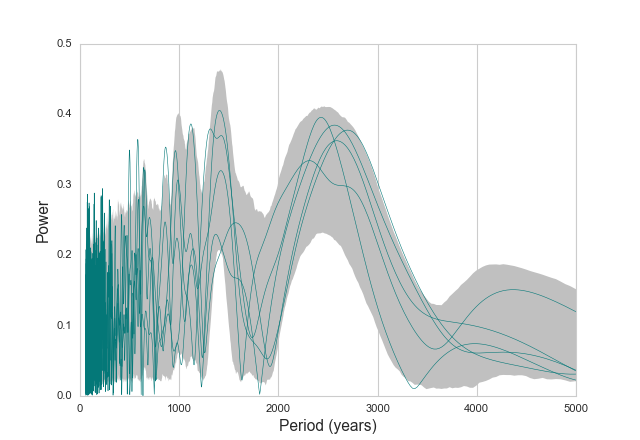

```python
# Make a plot of the confidence bands along a few random periodograms

%matplotlib notebook
ax = plt.axes()
#ax.spines["top"].set_visible(False)
#ax.spines["right"].set_visible(False)
ax.get_xaxis().tick_bottom()
ax.get_yaxis().tick_left()
plt.fill_between(2*np.pi/f, pgramQ[1,:], pgramQ[0,:], facecolor='Silver',edgecolor='Silver',lw=0.0)  # see http://stackoverflow.com/questions/14143092/why-does-matplotlib-fill-between-draw-edgelines-only-on-a-pdf
CI = mpatches.Patch(color='silver') # create proxy artist for labeling
lbl = ('95% CI','sample paths')

#plot a few random paths
nl = 5
idx = np.random.randint(nchrons+1, size=nl)
l = plt.plot(2*np.pi/f,pgram_norm[idx,:].T,lw=0.5,color = '#047878')

# plot the legend
#lg = plt.legend((CI,l[1]),lbl,loc='upper left'); lg.draw_frame(False)
plt.grid(axis='y'); plt.xlim(0,5000) #plt.ylim(0,10000);  plt.xlim(0,900)
plt.xlabel(r'Period (years)',fontsize=14); plt.ylabel(r'Power',fontsize=14);
```

```python
# OPTIONAL: save the figure
# Save the figure
newdir = createdir(lpd.path,'Figures')
plt.savefig(newdir+'/plot_spectra_'+filename+'.eps', bbox_inches = 'tight', pad_inches =0.25)
```

## Summary

Summarize the results below and export various csv file for further use

```python
# Find the peaks for each Monte-Carlo age models and the percent variance in each band of interest
from detect_peaks import detect_peaks
from scipy.integrate import simps

# initiate the matrices
peak_sub1 = np.zeros(age_paleo_nan.shape[0])
peak_sub2 = np.zeros(age_paleo_nan.shape[0])
peak_sub3 = np.zeros(age_paleo_nan.shape[0])

percent_var1 = np.zeros(age_paleo_nan.shape[0])
percent_var2 = np.zeros(age_paleo_nan.shape[0])
percent_var3 = np.zeros(age_paleo_nan.shape[0])

for index in np.arange(0,age_paleo_nan.shape[0],1): #step over all the possible spectres
    # Concentrate on the 900-1200 yr band
    pgram_sub1 = pgram_norm[index , np.min(np.where(2*np.pi/f<1200)):np.max(np.where(2*np.pi/f>900))]
    f_sub1 = f[np.min(np.where(2*np.pi/f<1200)):np.max(np.where(2*np.pi/f>900))]
    ind_sub1 = detect_peaks(pgram_sub1, show = False, mpd = pgram_sub1.shape[0])
    if not ind_sub1:
        peak_sub1[index] = np.nan
        percent_var1[index]= np.nan
    else:
        peak_sub1[index] = 2*np.pi/f_sub1[ind_sub1]
        percent_var1[index] = simps(pgram_sub1,f_sub1)/simps(pgram_norm[index,:], f)

    # Concentrate on the 1200-2000 yr band
    pgram_sub2 = pgram_norm[index , np.min(np.where(2*np.pi/f<2000)):np.max(np.where(2*np.pi/f>1200))]
    f_sub2 = f[np.min(np.where(2*np.pi/f<2000)):np.max(np.where(2*np.pi/f>1200))]
    ind_sub2 = detect_peaks(pgram_sub2, show = False, mpd = pgram_sub2.shape[0])
    if not ind_sub2:
        peak_sub2[index] = np.nan
        percent_var2[index]= np.nan
    else:
        peak_sub2[index] = 2*np.pi/f_sub2[ind_sub2]
        percent_var2[index] = simps(pgram_sub2,f_sub2)/simps(pgram_norm[index,:], f)

    # Concentrate on the 2000-3000 yr band
    pgram_sub3 = pgram_norm[index , np.min(np.where(2*np.pi/f<3000)):np.max(np.where(2*np.pi/f>2000))]
    f_sub3 = f[np.min(np.where(2*np.pi/f<3000)):np.max(np.where(2*np.pi/f>2000))]
    ind_sub3 = detect_peaks(pgram_sub3, show = False, mpd = pgram_sub3.shape[0])
    if not ind_sub3:
        peak_sub3[index] = np.nan
        percent_var3[index]= np.nan
    else:
        peak_sub3[index] = 2*np.pi/f_sub3[ind_sub3]
        percent_var3[index] = simps(pgram_sub3,f_sub3)/simps(pgram_norm[index,:], f)
```

```python
# Export the age as csv
np.savetxt(record+"_age.csv",age_paleo_nan,delimiter=",")
np.savetxt(record+"_depth.csv",depth_paleo[val_idx],delimiter=",")

# Create a text file summarizing the statistics of the spectral analysis
text_file = open(os.path.join(dir,record+"_Spectral_Analysis_Summary.txt"),"w")
text_file.write("900-1200 year band")
text_file.write("\n\nThere is a peak in this frequency band in " + \
                str(round(np.count_nonzero(~np.isnan(peak_sub1))/age_paleo_nan.shape[0]*100,0))+ \
                "% of the Monte-Carlo simulations.")
text_file.write("\nThe median periodicity is " + str(round(mquantiles(peak_sub1,prob=0.5,axis=0)[0],0)) +\
               " years with a 95% confidence band of " + str(round(mquantiles(peak_sub1,prob=0.025,axis=0)[0],0)) +\
               " - " +str(round(mquantiles(peak_sub1,prob=0.975,axis=0)[0],0)) + " years.")
text_file.write("\nThis frequency band represents between " + str(round(np.nanmin(percent_var1*100),1)) +\
                " and " + str(round(np.nanmax(percent_var1*100),1))+ "% of the total variance.")
text_file.write("\n\n1200-2000 year band")
text_file.write("\n\nThere is a peak in this frequency band in " + \
                str(round(np.count_nonzero(~np.isnan(peak_sub2))/age_paleo_nan.shape[0]*100,0))+ \
                "% of the Monte-Carlo simulations.")
text_file.write("\nThe median periodicity is " + str(round(mquantiles(peak_sub2,prob=0.5,axis=0)[0],0)) +\
               " years with a 95% confidence band of " + str(round(mquantiles(peak_sub2,prob=0.025,axis=0)[0],0)) +\
               " - " +str(round(mquantiles(peak_sub2,prob=0.975,axis=0)[0],0)) + " years.")
text_file.write("\nThis frequency band represents between " + str(round(np.nanmin(percent_var2*100),1)) +\
                " and " + str(round(np.nanmax(percent_var2*100),1))+ "% of the total variance.")
text_file.write("\n\n2000-3000 year band")
text_file.write("\n\nThere is a peak in this frequency band in " + \
                str(round(np.count_nonzero(~np.isnan(peak_sub3))/age_paleo_nan.shape[0]*100,0))+ \
                "% of the Monte-Carlo simulations.")
text_file.write("\nThe median periodicity is " + str(round(mquantiles(peak_sub3,prob=0.5,axis=0)[0],0)) +\
               " years with a 95% confidence band of " + str(round(mquantiles(peak_sub3,prob=0.025,axis=0)[0],0)) +\
               " - " +str(round(mquantiles(peak_sub3,prob=0.975,axis=0)[0],0)) + " years.")
text_file.write("\nThis frequency band represents between " + str(round(np.nanmin(percent_var3*100),1)) +\
                " and " + str(round(np.nanmax(percent_var3*100),1))+ "% of the total variance.")
text_file.close()

# Create another text file to look for the number easily
text_file = open(os.path.join(dir,record+"_spectral.txt"),"w")
text_file.write(str(round(mquantiles(peak_sub1,prob=0.5,axis=0)[0],0)) + "," +\
               str(round(mquantiles(peak_sub1,prob=0.975,axis=0)[0],0)-round(mquantiles(peak_sub1,prob=0.025,axis=0)[0],0))\
               + "," + str(round(np.count_nonzero(~np.isnan(peak_sub1))/age_paleo_nan.shape[0]*100,1)) + "," +\
               str(round(np.nanmean(percent_var1*100),1)))
text_file.write("\n"+ str(round(mquantiles(peak_sub2,prob=0.5,axis=0)[0],0)) + "," +\
               str(round(mquantiles(peak_sub2,prob=0.975,axis=0)[0],0)-round(mquantiles(peak_sub2,prob=0.025,axis=0)[0],0))\
               + "," + str(round(np.count_nonzero(~np.isnan(peak_sub2))/age_paleo_nan.shape[0]*100,1)) + "," +\
               str(round(np.nanmean(percent_var2*100),1)))
text_file.write("\n"+ str(round(mquantiles(peak_sub3,prob=0.5,axis=0)[0],0)) + "," +\
               str(round(mquantiles(peak_sub3,prob=0.975,axis=0)[0],0)-round(mquantiles(peak_sub3,prob=0.025,axis=0)[0],0))\
               + "," + str(round(np.count_nonzero(~np.isnan(peak_sub3))/age_paleo_nan.shape[0]*100,1)) + "," +\
               str(round(np.nanmean(percent_var3*100),1)))
text_file.close()
```

# Programmer's corner

Use the cell below to have a look at the data and variables in the workspace

```python
whos
```

```
Variable            Type                 Data/Info
--------------------------------------------------
CI                  Patch                Patch'>
Id                  list                 n=14
age_chron           ndarray              1000x14: 14000 elems, type `float64`, 112000 bytes (109.375 kb)
age_chron_Q         MaskedArray          [[  5.00000000e+00   1.46<...>50e+04   1.28545950e+04]]
age_paleo           ndarray              1000x455: 455000 elems, type `float64`, 3640000 bytes (3.47137451171875 Mb)
age_paleo_Q         MaskedArray          [[   -43.       -32.595  <...>   10263.785  10292.595]]
age_paleo_nan       ndarray              1000x337: 337000 elems, type `float64`, 2696000 bytes (2.57110595703125 Mb)
ax                  AxesSubplot          Axes(0.125,0.1;0.775x0.8)
cartopy             module               <module 'cartopy' from '/<...>ges/cartopy/__init__.py'>
ccrs                module               <module 'cartopy.crs' fro<...>packages/cartopy/crs.py'>
corr                float64              19.0
corr_14C            ndarray              14: 14 elems, type `float64`, 112 bytes
corr_err            float64              58.2433319298
createdir           function             <function createdir at 0x125e24048>
data                DataFrame                 MapNo       Lon     <...>sland           1922
depth               Series               0      12.0\n1      55.0\<...>me: depth, dtype: float64
depth_chron         ndarray              14: 14 elems, type `float64`, 112 bytes
depth_paleo         ndarray              455: 455 elems, type `float64`, 3640 bytes
depth_text          str                  MD98-2181_depth.txt
df_chron_l          DataFrame                 age14c  age14cuncert<...>Gs  \n13  941.0      Gs
df_data_l           DataFrame                     age  age_calyrbp<...>\n[455 rows x 11 columns]
dir                 str                  /Users/deborahkhider/Docu<...>181.Khider.2014/Age Model
ensembleArray       ndarray              455x1001: 455455 elems, type `float64`, 3643640 bytes (3.4748458862304688 Mb)
ensembleProxy       ndarray              337x1001: 337337 elems, type `float64`, 2698696 bytes (2.5736770629882812 Mb)
enumerateLipds      function             <function enumerateLipds at 0x125e07e18>
err_14C             ndarray              14: 14 elems, type `float64`, 112 bytes
filename            str                  MD982181.Khider.2014.lpd
findLipds           function             <function findLipds at 0x125e240d0>
getDataframe        function             <function getDataframe at 0x125e07c80>
get_recursively     function             <function get_recursively at 0x11b7779d8>
i                   int64                13
idx                 ndarray              10: 10 elems, type `int64`, 80 bytes
iter                int                  10000
l                   list                 n=10
label               str                  mg
lbl                 tuple                n=4
lg                  Legend               Legend
lipd_m              dict                 n=11
```

[output cut: 18 more lines]

```
radiocarbonU        Series               0     110.0\n1     200.0\<...>certainty, dtype: float64
readHeaders         function             <function readHeaders at 0x125e07bf8>
record              str                  MD98-2181
recordID            function             <function recordID at 0x11b777950>
selectVariable      function             <function selectVariable at 0x125e07b70>
sns                 module               <module 'seaborn' from '/<...>ges/seaborn/__init__.py'>
stopFunction        function             <function stopFunction at 0x125e07a60>
sys                 module               <module 'sys' (built-in)>
v                   ErrorbarContainer    <Container object of 3 artists>
val_idx             list                 n=337
valuesloc           function             <function valuesloc at 0x11b777a60>
var_idx             int                  4
y_values            Series               0      5.21\n1      5.04\<...>nName: mg, dtype: float64
yerr_high           MaskedArray          [ 191.595  159.595  141.3<...>32.5    195.595  821.095]
yerr_low            MaskedArray          [  99.     204.595  136. <...>37.88   149.38   809.64 ]
```